# HOMEWORK 1

Tomasz Cheda

I chose the phoneme dataset and developed three models, plus TabPFN. I performed a short EDA, attempted hyperparameter search, and reported the final results. For ease of reproducibility, random operations are seeded wherever feasible.

## Dataset

Phoneme is a 1993 dataset containing sound properties of vowels as pronounced in different syllables. Each vowel in each context yields three samples, corresponding to different moments in time during pronunciation. The class label is whether a vowel is nasal (0) or oral (1). Details are available at https://www.openml.org/search?type=data&sort=runs&id=1489&status=active

There are 5 continuous numerical features plus the class feature, and 5404 samples. There are no missing values. The data is already near zero-mean and unit variance.

There are 3818 nasal and 1586 oral samples, yielding a 2.41 imbalance ratio. A dummy classifier would result in 70% accuracy

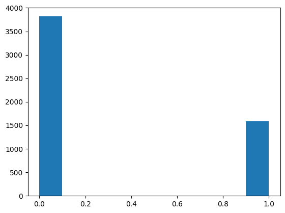

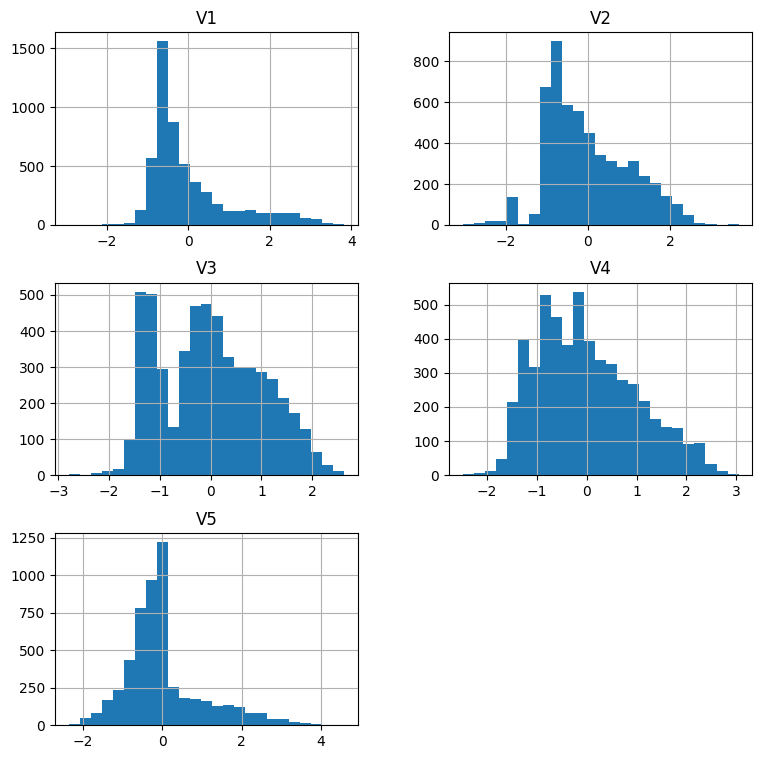

Some features are weakly correlated

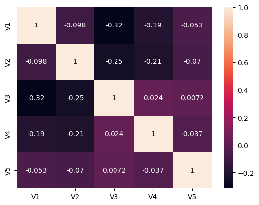

The dataset was split 90/10 train/test. For TabPFN, the training set was cropped to 1000 samples as suggested by an error message (technical limitation of the model)

Hyperparameter search with 5-fold CV on training set was attempted for those 3, but did not identify noticeably better parameters that the defaults. The final results are reported for the defaults.

The models were evaluated with sklearn built-in accuracy, precision, recall, F1, and AUC ROC.

**Results for Logistic Regression:**

Accuracy Score: 0.7208872458410351

Precision Score: 0.584070796460177

Recall Score: 0.38823529411764707

F1 Score: 0.46643109540636046

AUC-ROC Score: 0.7979546535595371

**Results for XGBoost:**

Accuracy Score: 0.8927911275415896

Precision Score: 0.8333333333333334

Recall Score: 0.8235294117647058

F1 Score: 0.8284023668639053

AUC-ROC Score: 0.9502933248771207

**Results for Random Forest:**

Accuracy Score: 0.9038817005545287

Precision Score: 0.8641975308641975

Recall Score: 0.8235294117647058

F1 Score: 0.8433734939759034

AUC-ROC Score: 0.9612335500237831

**Results for TabPFN:**

Accuracy Score: 0.8521256931608133

Precision Score: 0.774390243902439

Recall Score: 0.7470588235294118

F1 Score: 0.7604790419161677

AUC-ROC Score: 0.920469319803393

For an imbalanced dataset such as this one, the most reliable measure is AUCROC. Ranking by it:

1. Random Forest: 0.9612335500237831
2. XGBoost: 0.9502933248771207
3. TabPFN: 0.920469319803393
4. Logistic Regression: 0.7979546535595371

# APPENDIX

```python
!pip install openml
!pip install tabpfn
```

```python
import openml
import pandas as pd
from openml.datasets import get_dataset
```

## Dataset

```python
phoneme, *_ = openml.datasets.get_dataset(1489).get_data() #openml id for phoneme dataset
```

```python
phoneme
```

|  | V1 | V2 | V3 | V4 | V5 | Class |
| --- | --- | --- | --- | --- | --- | --- |
| 0 | 0.489927 | -0.451528 | -1.047990 | -0.598693 | -0.020418 | 1 |
| 1 | -0.641265 | 0.109245 | 0.292130 | -0.916804 | 0.240223 | 1 |
| 2 | 0.870593 | -0.459862 | 0.578159 | 0.806634 | 0.835248 | 1 |
| 3 | -0.628439 | -0.316284 | 1.934295 | -1.427099 | -0.136583 | 1 |
| 4 | -0.596399 | 0.015938 | 2.043206 | -1.688448 | -0.948127 | 1 |
| ... | ... | ... | ... | ... | ... | ... |
| 5399 | -0.658318 | 1.331760 | -0.081621 | 1.794253 | -1.082181 | 1 |
| 5400 | -0.044375 | -0.010512 | 0.030989 | -0.019379 | 1.281061 | 2 |
| 5401 | 0.246882 | -0.793228 | 1.190101 | 1.423194 | -1.303036 | 2 |
| 5402 | -0.778907 | -0.383111 | 1.727029 | -1.432389 | -1.208085 | 1 |
| 5403 | -0.794604 | -0.640053 | 0.632221 | 0.720280 | -1.231182 | 2 |

5404 rows × 6 columns

Phoneme is a 1993 dataset containing sound properties of vowels as pronounced in different syllables. Each vowel in each context yields three samples, corresponding to different moments in time during pronunciation. The class label is whether a vowel is nasal (0) or oral (1). Details are available at https://www.openml.org/search?type=data&sort=runs&id=1489&status=active

There are 5 continuous numerical features plus the class feature, and 5404 samples. There are no missing values. The data is already near zero-mean and unit variance.

```python
phoneme.head()
```

|  | V1 | V2 | V3 | V4 | V5 | Class |
| --- | --- | --- | --- | --- | --- | --- |
| 0 | 0.489927 | -0.451528 | -1.047990 | -0.598693 | -0.020418 | 1 |
| 1 | -0.641265 | 0.109245 | 0.292130 | -0.916804 | 0.240223 | 1 |
| 2 | 0.870593 | -0.459862 | 0.578159 | 0.806634 | 0.835248 | 1 |
| 3 | -0.628439 | -0.316284 | 1.934295 | -1.427099 | -0.136583 | 1 |
| 4 | -0.596399 | 0.015938 | 2.043206 | -1.688448 | -0.948127 | 1 |

```python
phoneme.info()
```

```
<class 'pandas.core.frame.DataFrame'>
RangeIndex: 5404 entries, 0 to 5403
Data columns (total 6 columns):
 #   Column  Non-Null Count  Dtype
---  ------  --------------  -----
 0   V1      5404 non-null   float64
 1   V2      5404 non-null   float64
 2   V3      5404 non-null   float64
 3   V4      5404 non-null   float64
 4   V5      5404 non-null   float64
 5   Class   5404 non-null   category
dtypes: category(1), float64(5)
memory usage: 216.6 KB
```

```python
phoneme.describe()
```

|  | V1 | V2 | V3 | V4 | V5 |
| --- | --- | --- | --- | --- | --- |
| count | 5.404000e+03 | 5.404000e+03 | 5.404000e+03 | 5.404000e+03 | 5.404000e+03 |
| mean | 3.330866e-09 | 5.551443e-09 | 6.106588e-09 | -9.437454e-09 | -6.698742e-08 |
| std | 1.000000e+00 | 1.000000e+00 | 1.000000e+00 | 1.000000e+00 | 1.000000e+00 |
| min | -2.933743e+00 | -3.038709e+00 | -2.795869e+00 | -2.485340e+00 | -2.367461e+00 |
| 25% | -6.697555e-01 | -7.790800e-01 | -9.505788e-01 | -7.583255e-01 | -5.405418e-01 |
| 50% | -3.801605e-01 | -2.150985e-01 | -3.861800e-02 | -1.422555e-01 | -2.127475e-01 |
| 75% | 3.149040e-01 | 7.136990e-01 | 7.771393e-01 | 6.759035e-01 | 2.045420e-01 |
| max | 3.828575e+00 | 3.664763e+00 | 2.630868e+00 | 3.046948e+00 | 4.586666e+00 |

```python
phoneme.shape
```

```
(5404, 6)
```

```python
phoneme['Class']=phoneme['Class'].map({'1':0, '2':1})
```

```python
X = phoneme[['V1', 'V2', 'V3', 'V4', 'V5']]
Y = phoneme['Class']
```

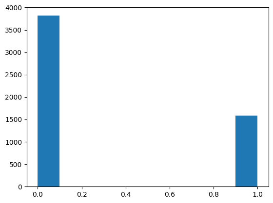

```python
import matplotlib.pyplot as plt
plt.hist(Y)
```

```python
Y.describe()
```

```
count     5404
unique       2
top          0
freq      3818
Name: Class, dtype: int64
```

```python
count_1 = sum(Y==1)
count_1
```

```
1586
```

```python
count_0 = sum(Y==0)
count_0
```

```
3818
```

```python
count_0/count_1
```

```
2.407313997477932
```

There are 3818 nasal and 1586 oral samples, yielding a 2.41 ratio.

```python
count_0/(count_0+count_1)
```

```
0.7065136935603257
```

A dummy classifier would result in 70% accuracy

```
array([[<Axes: title={'center': 'V1'}>, <Axes: title={'center': 'V2'}>],
       [<Axes: title={'center': 'V3'}>, <Axes: title={'center': 'V4'}>],
       [<Axes: title={'center': 'V5'}>, <Axes: >]], dtype=object)
```

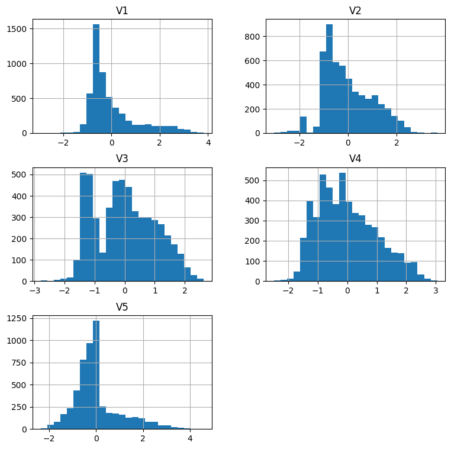

```python
phoneme.hist(bins=25, figsize=(9,9))
```

```python
import numpy as np
```

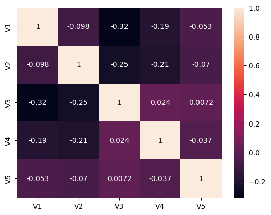

```python
import seaborn as sns
import matplotlib.pyplot as plt

sns.heatmap(phoneme.corr(), annot=True)
```

```python
phoneme.isnull().sum()
```

```
V1       0
V2       0
V3       0
V4       0
V5       0
Class    0
dtype: int64
```

```python
RANDOM_SEED=1337
```

```python
from sklearn.model_selection import train_test_split
X_train, X_test, Y_train, Y_test = train_test_split(X, Y, test_size=0.1, random_state=RANDOM_SEED)
```

## Logistic regression exploration

```python
from sklearn.pipeline import Pipeline
from sklearn.model_selection import cross_validate
from sklearn.preprocessing import StandardScaler
from sklearn.linear_model import LogisticRegression
from sklearn.ensemble import RandomForestClassifier
from sklearn.model_selection import RandomizedSearchCV
```

```python
from sklearn.metrics import make_scorer, accuracy_score, precision_score, recall_score, f1_score, roc_auc_score
def score_pipeline(model):
  scoring = {
      'accuracy': make_scorer(accuracy_score),
      'precision': make_scorer(precision_score),
      'recall': make_scorer(recall_score),
      'f1': make_scorer(f1_score),
      'roc_auc': make_scorer(roc_auc_score, needs_proba=True)
  }

  results = cross_validate(model, X_train, Y_train, cv=5, scoring=scoring)
  accuracy_scores = results['test_accuracy']
  precision_scores = results['test_precision']
  recall_scores = results['test_recall']
  f1_scores = results['test_f1']
  roc_auc_scores = results['test_roc_auc']
  print("Accuracy Scores:", accuracy_scores)
  print("Precision Scores:", precision_scores)
  print("Recall Scores:", recall_scores)
  print("F1 Scores:", f1_scores)
  print("AUC-ROC Scores:", roc_auc_scores)
  return results
```

```python
np.random.seed(42)
model = Pipeline([
    ('scaler', StandardScaler()), #in case you're wondering this properly ignores Y
    ('classifier', LogisticRegression())
])
res = score_pipeline(model)
```

```
Accuracy Scores: [0.75436793 0.74100719 0.76053443 0.75823045 0.74382716]
Precision Scores: [0.60185185 0.56828194 0.61643836 0.6        0.58095238]
Recall Scores: [0.45936396 0.45583039 0.47535211 0.50883392 0.43109541]
F1 Scores: [0.52104208 0.50588235 0.53677932 0.55066922 0.49492901]
AUC-ROC Scores: [0.81489732 0.79649716 0.80243873 0.8388508  0.81848533]
```

Including weighing significantly improves recall, but does not improve auc-roc, weird.

```python
np.random.seed(42)
model = Pipeline([
    ('scaler', StandardScaler()), #in case you're wondering this properly ignores Y
    ('classifier', LogisticRegression(class_weight='balanced')) #we don't know the true imbalance ratio, so use empirical in each fold
])

res = score_pipeline(model)
```

```
Accuracy Scores: [0.74306269 0.69989723 0.72250771 0.74176955 0.72633745]
Precision Scores: [0.54198473 0.48997773 0.51643192 0.5361991  0.52      ]
Recall Scores: [0.75265018 0.77738516 0.77464789 0.83745583 0.78091873]
F1 Scores: [0.63017751 0.6010929  0.61971831 0.6537931  0.62429379]
AUC-ROC Scores: [0.81332002 0.79490961 0.80147284 0.83710196 0.81505434]
```

RandomForest

```python
np.random.seed(42)
model = Pipeline([
    ('scaler', StandardScaler()), #in case you're wondering this properly ignores Y
    ('classifier', RandomForestClassifier()) #we don't know the true imbalance ratio, so use empirical in each fold
])

res = score_pipeline(model)
```

```
Accuracy Scores: [0.88900308 0.90750257 0.90750257 0.89506173 0.91563786]
Precision Scores: [0.81818182 0.83859649 0.85661765 0.85490196 0.86281588]
Recall Scores: [0.795053   0.84452297 0.82042254 0.77031802 0.84452297]
F1 Scores: [0.80645161 0.8415493  0.8381295  0.81040892 0.85357143]
AUC-ROC Scores: [0.94941619 0.95684437 0.96554764 0.95929729 0.96404632]
```

```python
np.random.seed(42)
model = Pipeline([
    ('scaler', StandardScaler()), #in case you're wondering this properly ignores Y
    ('classifier', RandomForestClassifier(random_state=42))
])

param_grid = {
    'classifier__n_estimators': [10, 50, 100],
    'classifier__max_depth': [None, 10, 20, 30],
    'classifier__min_samples_split': [2, 5, 10],
    'classifier__min_samples_leaf': [1, 2, 4],
    'classifier__max_features': [2, 3],
    'classifier__bootstrap': [True, False]
}

hp_search = RandomizedSearchCV(model, param_grid, cv=5, n_iter=30, scoring='roc_auc', random_state=42)
```

```python
hp_search.fit(X_train, Y_train)
```

```
RandomizedSearchCV(cv=5,
                   estimator=Pipeline(steps=[('scaler', StandardScaler()),
                                             ('classifier',
                                              RandomForestClassifier(random_state=42))]),
                   n_iter=30,
                   param_distributions={'classifier__bootstrap': [True, False],
                                        'classifier__max_depth': [None, 10, 20,
                                                                  30],
                                        'classifier__max_features': [2, 3],
                                        'classifier__min_samples_leaf': [1, 2,
                                                                         4],
                                        'classifier__min_samples_split': [2, 5,
                                                                          10],
                                        'classifier__n_estimators': [10, 50,
                                                                     100]},
                   random_state=42, scoring='roc_auc')
```

```python
hp_search.best_params_
```

```
{'classifier__n_estimators': 50,
 'classifier__min_samples_split': 2,
 'classifier__min_samples_leaf': 1,
 'classifier__max_features': 2,
 'classifier__max_depth': 20,
 'classifier__bootstrap': False}
```

```python
hp_search.best_score_
```

```
0.9601337283137376
```

```python
np.random.seed(42)
model = Pipeline([
    ('scaler', StandardScaler()), #in case you're wondering this properly ignores Y
    ('classifier', RandomForestClassifier(n_estimators=50, min_samples_split=2, min_samples_leaf=1, max_features=2, max_depth=20, bootstrap=False)) #we don't know the true imbalance ratio, so use empirical in each fold
])
res = score_pipeline(model)
```

```
Accuracy Scores: [0.90133607 0.90853032 0.90441932 0.89609053 0.90946502]
Precision Scores: [0.84758364 0.84642857 0.84727273 0.85826772 0.84697509]
Recall Scores: [0.80565371 0.83745583 0.82042254 0.77031802 0.8409894 ]
F1 Scores: [0.82608696 0.84191829 0.83363148 0.81191806 0.84397163]
AUC-ROC Scores: [0.95503662 0.95918984 0.96736697 0.95913317 0.96475406]
```

```python
#the results dont match the ones in crossval exactly as we are not seeding the kfold directly, but are reproducible run to run
```

## XGBOOST Exploration

```python
import xgboost as xgb

np.random.seed(42)
model = Pipeline([
    ('scaler', StandardScaler()), #in case you're wondering this properly ignores Y
    ('classifier', xgb.XGBClassifier())
])
res = score_pipeline(model)
```

```
Accuracy Scores: [0.89414183 0.89105858 0.89825283 0.89300412 0.90123457]
Precision Scores: [0.81468531 0.80204778 0.84644195 0.84555985 0.82807018]
Recall Scores: [0.82332155 0.83038869 0.79577465 0.77385159 0.83392226]
F1 Scores: [0.81898067 0.81597222 0.82032668 0.80811808 0.83098592]
AUC-ROC Scores: [0.94576228 0.94628975 0.96127783 0.95129419 0.96070507]
```

```python
from scipy.stats import randint as sp_randint
param_dist = {
    'classifier__n_estimators': sp_randint(10, 200),
    'classifier__learning_rate': [0.01, 0.1, 0.2, 0.3, 0.5],
    'classifier__max_depth': sp_randint(3, 10),
    'classifier__min_child_weight': sp_randint(1, 10),
    'classifier__subsample': [0.5, 0.7, 0.8, 0.9, 1.0],
    'classifier__colsample_bytree': [0.5, 0.7, 0.8, 0.9, 1.0],
    'classifier__gamma': [0, 0.1, 0.2, 0.3, 0.4],
    'classifier__reg_alpha': [0, 0.1, 0.2, 0.3, 0.4],
    'classifier__reg_lambda': [0, 0.1, 0.2, 0.3, 0.4],
    'classifier__scale_pos_weight': [1, 2, 3, 4, 5],
}
hp_search = RandomizedSearchCV(model, param_dist, cv=5, n_iter=30, n_jobs=-1, random_state=42, scoring='roc_auc')
hp_search.fit(X_train, Y_train)
```

```
RandomizedSearchCV(cv=5,
                   estimator=Pipeline(steps=[('scaler', StandardScaler()),
                                             ('classifier',
                                              XGBClassifier(base_score=None,
                                                            booster=None,
                                                            callbacks=None,
                                                            colsample_bylevel=None,
                                                            colsample_bynode=None,
                                                            colsample_bytree=None,
                                                            device=None,
                                                            early_stopping_rounds=None,
                                                            enable_categorical=False,
                                                            eval_metric=None,
                                                            feature_types=None,
                                                            gamma=None,
                                                            grow_policy=None,
                                                            impor...
                                        'classifier__min_child_weight': <scipy.stats._distn_infrastructure.rv_discrete_frozen object at 0x7fee50ebbc40>,
                                        'classifier__n_estimators': <scipy.stats._distn_infrastructure.rv_discrete_frozen object at 0x7fee50ed23b0>,
                                        'classifier__reg_alpha': [0, 0.1, 0.2,
                                                                  0.3, 0.4],
                                        'classifier__reg_lambda': [0, 0.1, 0.2,
                                                                   0.3, 0.4],
                                        'classifier__scale_pos_weight': [1, 2,
                                                                         3, 4,
                                                                         5],
                                        'classifier__subsample': [0.5, 0.7, 0.8,
                                                                  0.9, 1.0]},
                   random_state=42, scoring='roc_auc')
```

```python
hp_search.best_params_
```

```
{'classifier__colsample_bytree': 1.0,
 'classifier__gamma': 0.3,
 'classifier__learning_rate': 0.1,
 'classifier__max_depth': 8,
 'classifier__min_child_weight': 6,
 'classifier__n_estimators': 148,
 'classifier__reg_alpha': 0,
 'classifier__reg_lambda': 0,
 'classifier__scale_pos_weight': 4,
 'classifier__subsample': 0.8}
```

```python
hp_search.best_score_
```

```
0.9524409898297603
```

```python
np.random.seed(42)
model = Pipeline([
    ('scaler', StandardScaler()), #in case you're wondering this properly ignores Y
    ('classifier', xgb.XGBClassifier(colsample_bytree=1.0, gamma=0.3, learning_rate=0.1, max_depth=8, min_child_weight=6, n_estimators=148, reg_alpha=0, reg_lambda=0, scale_pos_weight=4, subsample=0.8))
])
res = score_pipeline(model)
```

```
Accuracy Scores: [0.88078109 0.87461459 0.88694758 0.87962963 0.88580247]
Precision Scores: [0.75535168 0.73469388 0.76204819 0.76265823 0.75146199]
Recall Scores: [0.87279152 0.89045936 0.89084507 0.85159011 0.90812721]
F1 Scores: [0.80983607 0.80511182 0.82142857 0.80467446 0.8224    ]
AUC-ROC Scores: [0.94408255 0.94884007 0.96262189 0.94924277 0.95741767]
```

TabPFN - not attempting crossval

## Final Results

```python
from tabpfn import TabPFNClassifier
```

```python
def score_single(model, xtrain, ytrain, xtest, ytest):
  model.fit(xtrain, ytrain)
  ypred = model.predict(xtest)
  yprob = model.predict_proba(xtest)[:, 1]
  accuracy = accuracy_score(ytest, ypred)
  precision = precision_score(ytest, ypred)
  recall = recall_score(ytest, ypred)
  f1 = f1_score(ytest, ypred)
  rocauc = roc_auc_score(ytest, yprob)

  print("Accuracy Score:", accuracy)
  print("Precision Score:", precision)
  print("Recall Score:", recall)
  print("F1 Score:", f1)
  print("AUC-ROC Score:", rocauc)
  return rocauc
```

TabPFN

```python
np.random.seed(42)

X_train_small = X_train[:1000]
Y_train_small = Y_train[:1000]
tabpfn_roc = score_single(TabPFNClassifier(), X_train_small, Y_train_small, X_test, Y_test) # tabfpn throws away data, but it just cant consume more on reasonable hardware, it's a model limitation
```

```
Loading model that can be used for inference only
Using a Transformer with 25.82 M parameters
Accuracy Score: 0.8521256931608133
Precision Score: 0.774390243902439
Recall Score: 0.7470588235294118
F1 Score: 0.7604790419161677
AUC-ROC Score: 0.920469319803393
```

Logistic Regression

```python
np.random.seed(42)
model = Pipeline([
    ('scaler', StandardScaler()),
    ('classifier', LogisticRegression())
])
lr_roc = score_single(model, X_train, Y_train, X_test, Y_test)
```

```
Accuracy Score: 0.7208872458410351
Precision Score: 0.584070796460177
Recall Score: 0.38823529411764707
F1 Score: 0.46643109540636046
AUC-ROC Score: 0.7979546535595371
```

Random Forest

```python
np.random.seed(42)
model = Pipeline([
    ('scaler', StandardScaler()),
    ('classifier', RandomForestClassifier())
])
rf_roc = score_single(model, X_train, Y_train, X_test, Y_test)
```

```
Accuracy Score: 0.9038817005545287
Precision Score: 0.8641975308641975
Recall Score: 0.8235294117647058
F1 Score: 0.8433734939759034
AUC-ROC Score: 0.9612335500237831
```

XGBoost

```python
np.random.seed(42)
model = Pipeline([
    ('scaler', StandardScaler()),
    ('classifier', xgb.XGBClassifier())
])
xgb_roc = score_single(model, X_train, Y_train, X_test, Y_test)
```

```
Accuracy Score: 0.8927911275415896
Precision Score: 0.8333333333333334
Recall Score: 0.8235294117647058
F1 Score: 0.8284023668639053
AUC-ROC Score: 0.9502933248771207
```